# SIR model with Gillespie algorithm

In this notebook, I try to simulate a simple Susceptible, Infected, Removed (SIR) model using the Gillespie algorithm. Much of this notebook is a translation of the Wikipedia page on the [Gillespie Algorithm](https://en.wikipedia.org/wiki/Gillespie_algorithm#Another_example:_The_SIR_epidemic_without_vital_dynamics), though the page is rather opaque and incomplete. I also got some good information from [this page](http://people.uleth.ca/~roussel/C4000foundations/slides/25stochsim.pdf), and [this paper](https://web.stanford.edu/~jhj1/teachingdocs/Jones-on-R0.pdf).

### Gillespie algorithm

The Gillespie algorithm works as follows:

1. Store initial population and rate constants, set $t=0$
2. Use the differential equation rates to generate random numbers $w_1, \ldots, w_{m-1}$ of the likelihood of an event in the next time window. $m$ is the number of compartment (for SIR this is 3)
3. Scale these to be probabilities by dividing by $W = \sum_j w_j$
4. Generate a random uniform number U and determine which window $0 < w_1 < w_1 + w_2 < \ldots < W$ it falls in
5. Set the new time to be $t$ plus a random exponential with rate $W$
6. Increment the events depending on which event $U$ decided occured.

### Notation

I will use the following notation:

- $N$ = size of the population
- $n_S(t)$ = number of susceptible people at time $t$
- $n_I(t)$ = number of infected people at time $t$
- $n_R(t)$ = number of removed people at time $t$
- $\alpha$ = rate parameter at which people transition from susceptible to infected
- $\beta$ = rate parameter at which people transition from infected to recovered

(Note the Wikipedia page also uses a $V$ which is not defined so I have set it to 1)

### Model

The model dynamics can be written as a set of ordinary differential equations:

$$\frac{d n_S}{dt} = -\alpha n_S n_I$$

$$\frac{d n_I}{dt} = \left( \alpha n_S - \beta \right) n_I$$
$$\frac{d n_R}{dt} = \beta n_I$$

### Creating sample realisations

I will now use the Gillespie algorithm to simulate a sample path for a given set of parameter values in R.

First I will set up the data values and rate parameters

```r
# Number of individuals in population
N = 100
# Max time value
T = 100
# Rate parameters
alpha = 0.05  # Rate S -> I
beta = 0.5 # Rate I -> R
# Initial value of infected population
n_I = 1
# Assum recoved is zero
n_R = 0
# So n_S is the remainder:
n_S = N - n_I
# Initial time value
t = 0
# Count of iterations
count = 1
```

Next create a holder for the values and set the seed

```r
library(tibble)
store = tibble(
  Time = rep(NA, T),
  Susceptible = rep(NA, T),
  Infected = rep(NA, T),
  Removed = rep(NA, T),
)
set.seed(123)
```

Now loop through to simulate values

```r
while(t < T) {
  # Stop if the number of infected is 0
  if(n_I == 0) break

  # Store data values
  store[count,] = c(t, n_S, n_I, n_R)
  count = count + 1

  # Compute values from differential equations
  w_1 = alpha * n_S * n_I
  w_2 = beta * n_I
  # Sum them
  W = w_1 + w_2

  # Increase time
  #dt = -log(runif(1)) / W
  dt = rexp(1, rate = W) # Original code used uniform generator
  t = t + dt

  # Now increment the svalues
  if(runif(1) < w_1 / W) {
    n_S = n_S - 1
    n_I = n_I + 1
  } else {
    n_I = n_I - 1
    n_R = n_R + 1
  }

}
```

### Plot results

Create a plot of the data with:

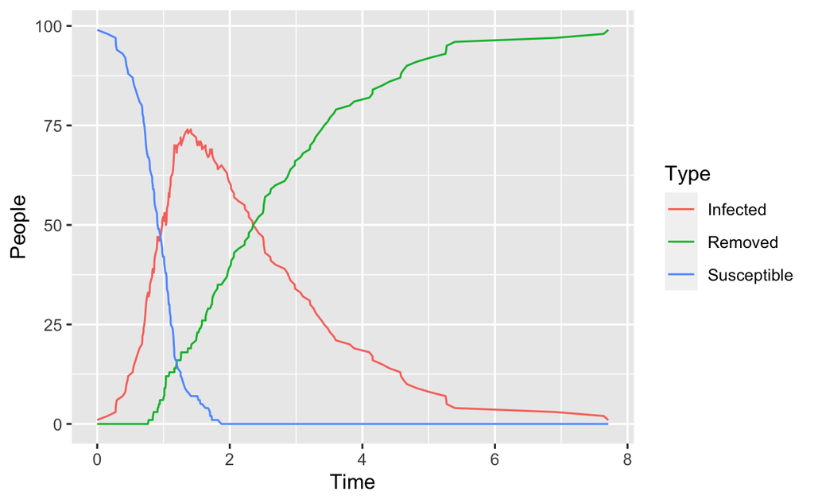

```r
library(tidyr)
library(ggplot2)
store %>%
  drop_na() %>%
  pivot_longer(names_to = 'Type',
                       values_to = 'People',
                       -Time) %>%
  ggplot(aes(x = Time, y = People, colour = Type)) +
  geom_line()
```